# HW 3

# Intro

One of the most pressing issues in America today is the disproportionate rates of incarceration of POC. To better understand this issue, I am going to analyze the ratio of average incarceration rates by US regions of black populations to white populations. This will show just *how much* more likely a POC are to be incarcerated than white people are.

# Values

This section will present some values/patterns that arose during this investigation. The average ratio of incarceration rate of black Americans to that of white Americans per year is shown in the table below:

| year | avg_btw_ratio |
| --- | --- |
| 1990 | 7.964570 |
| 1991 | 9.855091 |
| 1992 | 8.129004 |
| 1993 | 7.615478 |
| 1994 | 8.008328 |
| 1995 | 9.026798 |
| 1996 | 8.583930 |
| 1997 | 8.916552 |
| 1998 | 8.759001 |
| 1999 | 9.216676 |
| 2000 | 8.726419 |
| 2001 | 8.103472 |
| 2002 | 8.376356 |
| 2003 | 8.006779 |
| 2004 | 7.521657 |
| 2005 | 6.941423 |
| 2006 | 6.851525 |
| 2007 | 6.901230 |
| 2008 | 6.800744 |
| 2009 | 6.978182 |
| 2010 | 6.410972 |
| 2011 | 5.993603 |
| 2012 | 5.652468 |
| 2013 | 5.405914 |
| 2014 | 5.277901 |
| 2015 | 5.145619 |
| 2016 | 5.026144 |

The highest ratio in a single county in 2006 is 245.2083333. This can be compared the highest ratio in 2016 which was 183.2336182. The County and State which held this ratio was Mitchell County, NC. The change in average the ratio over most recent 10 years across all counties is -1.8253806.

# Trend Over Time

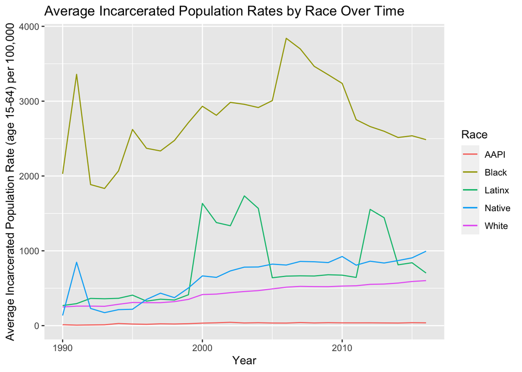

This chart shows how the average incarceration rates of various 5 races in America have changed from 1990 to 2016. While the rate for each race seems to be trending upward, it can be seen the rate of black Americans is significantly higher than that of any other race. It should also be noted that the rate for white Americans is one of the lowest.

# Comparing Statistics

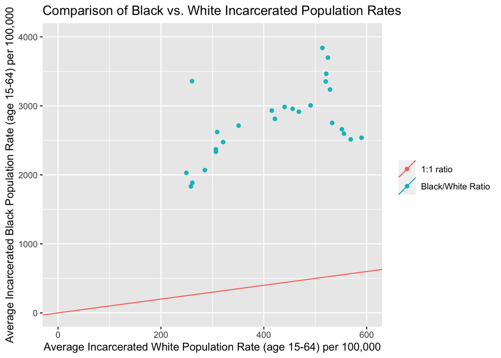

# Mapping The Issue in Washington State

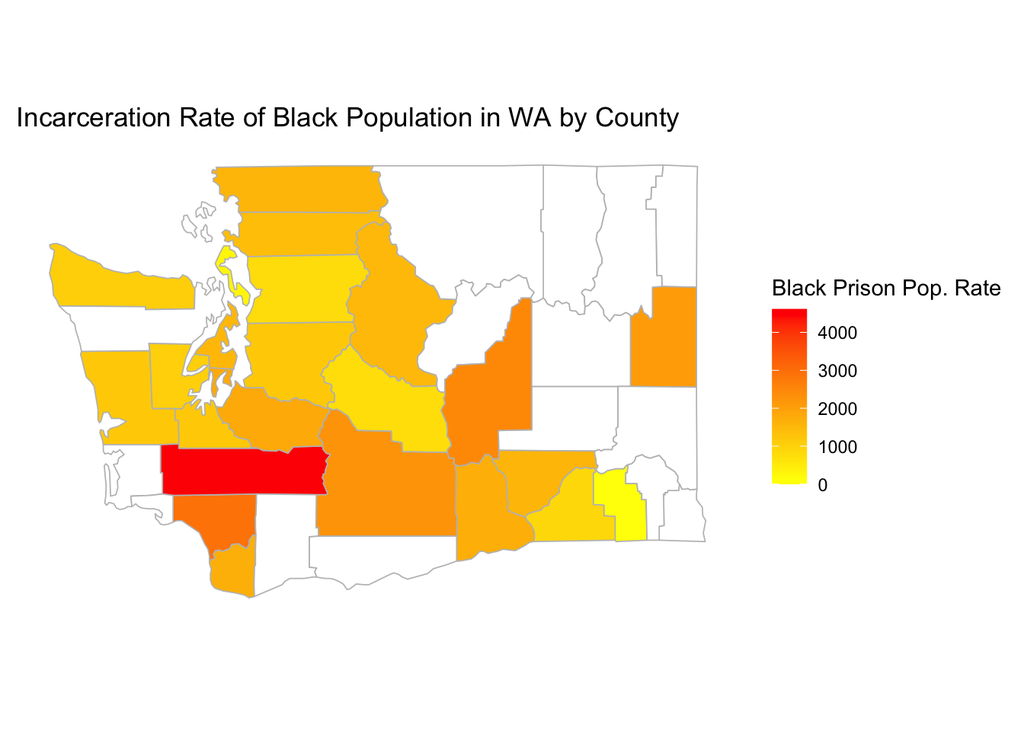

This map shows the incarceration rate of the black population by county in Washington State. The purpose of this is to show where the problem is the most prevalent in our home state.